# Movie Analysis Case Study

Webscaping using Rvest

Edwin Rosas

# Introduction

Using Data Scraping via Rvest, we are able to scrape multiple pages to extract the top 200 Action movies of all time according to IMDB. From each movie we were able to extract Movie statistics such as movie gross income, Metascore, Rating, total votes, and year of debut. We then conducted preliminary analysis of the data.

## Task

Using data visualizations we explore patterns and trends from our newly scraped data. We will also try to see the difference of Metascore (weighted Average) and IMDB rating (site specific)

[Click here](https://github.com/Edrosas24/IMDB_DataScrapingProj) to view Code

# Preparing Our Data

Our Data is directly taken from IMDB website. IMDB actively gathers information from and verify items with studios and filmmakers, but most of the information is user submitted.

**Dataset**: movies.200.csv

**License**: Made available via IMDB

**Time Frame of Data**: May 2022

## Quality of our Data Source

- **Reliability:** IMDB’s user submitted data is okay since the data fields of voting, metascore, and rating are subjective.
- **Originality:** This is a first party source since the data was scraped form IMDB
- **Comprehensive:** How comprehensive we wanted the data was dependent on how much of the webpage we wanted to scrape. For this analysis, the extracted fields were sufficient.
- **Current:** The data is as currents as when we decide to run our code again.
- **Cited**: The data has been cited by IMDB

# Processing our Data

For the majority of our analysis we used R to data scrape the IMDB website, and for visualizations.

## Our Working Data

|  | X | rank | name | year | rating | metascore | votes | gross | synopsis | cast |
| --- | --- | --- | --- | --- | --- | --- | --- | --- | --- | --- |
| 1 | 1 | 1 | Star Wars: Episode VII - The Force Awakens | (2015) | 7.8 | 80 | 910328 | $936.66M | \nAs a new threat to the galaxy rises, Rey, a desert scavenger, and Finn, an ex-stormtrooper, must join Han Solo and Chewbacca to search for the one hope of restoring peace. | Harrison Ford\n, Mark Hamill\n, Carrie Fisher\n, Adam Driver\n, Daisy Ridley\n, John Boyega\n, Oscar Isaac\n, Lupita Nyong'o\n, Andy Serkis\n, Domhnall Gleeson\n, Anthony Daniels\n, Max von Sydow\n, P… |
| 2 | 2 | 2 | Avengers: Endgame | (2019) | 8.4 | 78 | 1055957 | $858.37M | \nAfter the devastating events of Avengers: Infinity War (2018), the universe is in ruins. With the help of remaining allies, the Avengers assemble once more in order to reverse Thanos' actions and re… | Robert Downey Jr.\n, Chris Evans\n, Mark Ruffalo\n, Chris Hemsworth\n, Scarlett Johansson\n, Jeremy Renner\n, Don Cheadle\n, Paul Rudd\n, Benedict Cumberbatch\n, Chadwick Boseman\n, Brie Larson\n, Tom… |
| 3 | 3 | 3 | Avatar | (2009) | 7.8 | 83 | 1200087 | $760.51M | \nA paraplegic Marine dispatched to the moon Pandora on a unique mission becomes torn between following his orders and protecting the world he feels is his home. | Sam Worthington\n, Zoe Saldana\n, Sigourney Weaver\n, Stephen Lang\n, Michelle Rodriguez\n, Giovanni Ribisi\n, Joel David Moore\n, CCH Pounder\n, Wes Studi\n, Laz Alonso\n, Dileep Rao\n, Matt Gerald\n… |
| 4 | 4 | 4 | Black Panther | (2018) | 7.3 | 88 | 723719 | $700.06M | \nT'Challa, heir to the hidden but advanced kingdom of Wakanda, must step forward to lead his people into a new future and must confront a challenger from his country's past. | Chadwick Boseman\n, Michael B. Jordan\n, Lupita Nyong'o\n, Danai Gurira\n, Martin Freeman\n, Daniel Kaluuya\n, Letitia Wright\n, Winston Duke\n, Sterling K. Brown\n, Angela Bassett\n, Forest Whitaker\… |
| 5 | 5 | 5 | Avengers: Infinity War | (2018) | 8.4 | 68 | 1017415 | $678.82M | \nThe Avengers and their allies must be willing to sacrifice all in an attempt to defeat the powerful Thanos before his blitz of devastation and ruin puts an end to the universe. | Robert Downey Jr.\n, Chris Hemsworth\n, Mark Ruffalo\n, Chris Evans\n, Scarlett Johansson\n, Don Cheadle\n, Benedict Cumberbatch\n, Tom Holland\n, Chadwick Boseman\n, Zoe Saldana\n, Karen Gillan\n, To… |
| 6 | 6 | 6 | Jurassic World | (2015) | 6.9 | 59 | 621174 | $652.27M | \nA new theme park, built on the original site of Jurassic Park, creates a genetically modified hybrid dinosaur, the Indominus Rex, which escapes containment and goes on a killing spree. | Chris Pratt\n, Bryce Dallas Howard\n, Irrfan Khan\n, Vincent D'Onofrio\n, Ty Simpkins\n, Nick Robinson\n, Jake Johnson\n, Omar Sy\n, BD Wong\n, Judy Greer\n, Lauren Lapkus\n, Brian Tee\n, Katie McGrat… |

## Data Cleaning

1. Omit the the index column ‘X’
2. Fix ‘year’ format : Omit parenthesis and change to numeric data type
3. Fix ‘gross’ format : Omit non-numeric symbols to make data type to numeric

# Data Analysis and Visualization

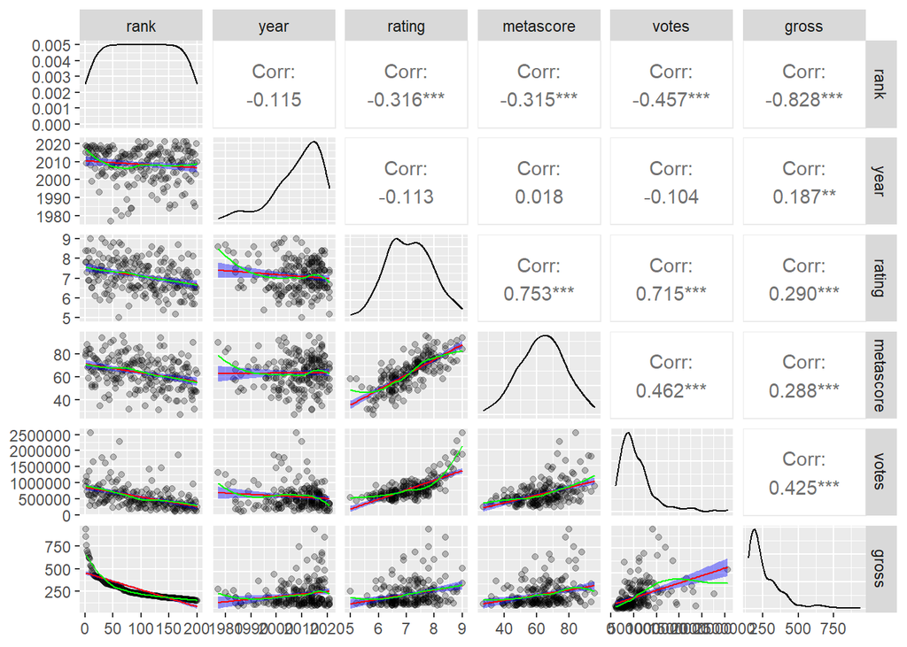

We see many patterns of interest from comparing all our fields

- Gross Income of a movie is correlated with year, both rating scores, and votes on the website rating.

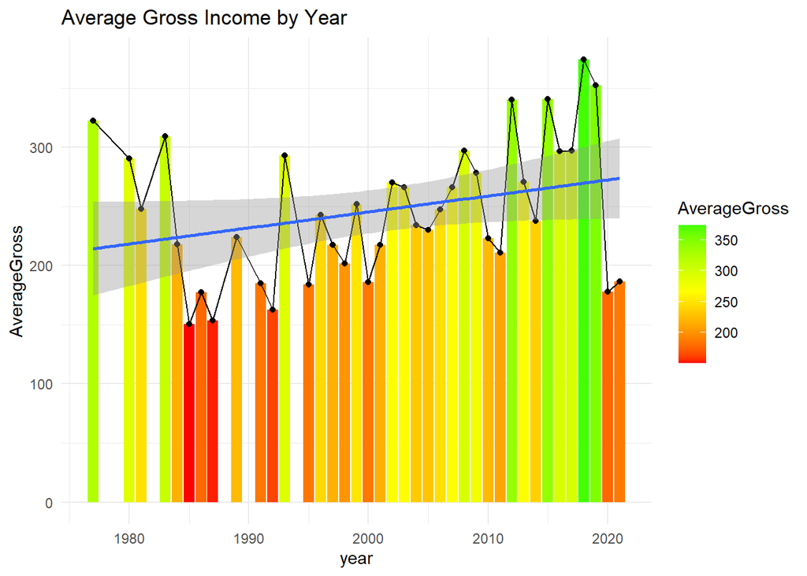

- We see an overall increase in gross income through out recent years, then in 2020 and 2021 we see the effects of the pandemic drastically lower gross income

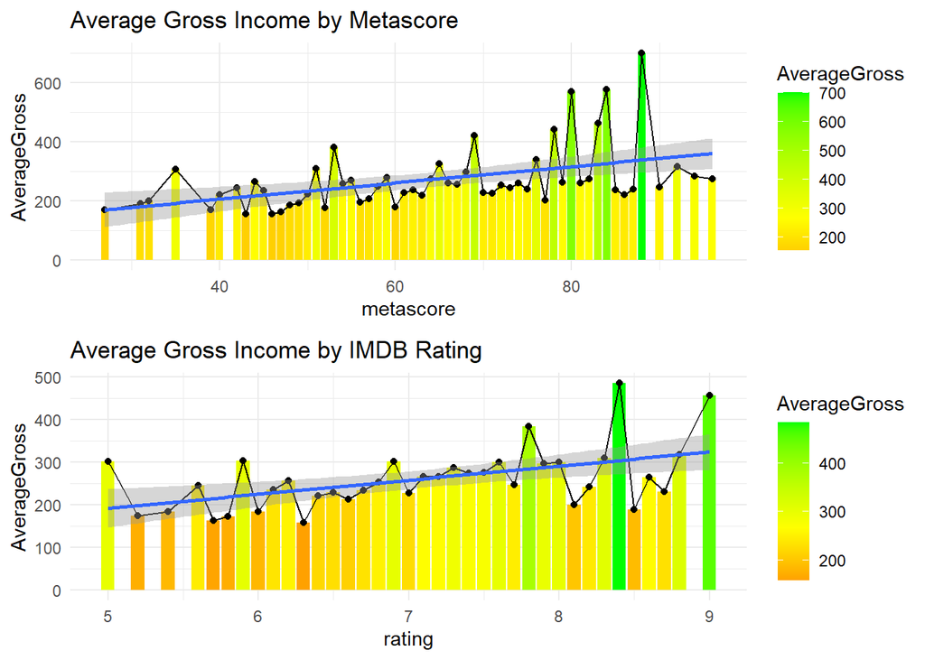

- Both scores look to have the same marginal correlation with Average Gross Income.

We have to score the quality of a movie on the IMDB website: Metascore and Rating. In order to compare these two scores, we create Rating Type column.

- In order to compare the the the two scores to the same scale, we multiply rating by 10 to get rating10

| RatingType | RatingVals | rank | name | year | rating | votes | gross | synopsis | cast |
| --- | --- | --- | --- | --- | --- | --- | --- | --- | --- |
| rating10 | 78 | 1 | Star Wars: Episode VII - The Force Awakens | 2015 | 7.8 | 910328 | 936.66 | \nAs a new threat to the galaxy rises, Rey, a desert scavenger, and Finn, an ex-stormtrooper, must join Han Solo and Chewbacca to search for the one hope of restoring peace. | Harrison Ford\n, Mark Hamill\n, Carrie Fisher\n, Adam Driver\n, Daisy Ridley\n, John Boyega\n, Oscar Isaac\n, Lupita Nyong'o\n, Andy Serkis\n, Domhnall Gleeson\n, Anthony Daniels\n, Max von Sydow\n, P… |
| metascore | 80 | 1 | Star Wars: Episode VII - The Force Awakens | 2015 | 7.8 | 910328 | 936.66 | \nAs a new threat to the galaxy rises, Rey, a desert scavenger, and Finn, an ex-stormtrooper, must join Han Solo and Chewbacca to search for the one hope of restoring peace. | Harrison Ford\n, Mark Hamill\n, Carrie Fisher\n, Adam Driver\n, Daisy Ridley\n, John Boyega\n, Oscar Isaac\n, Lupita Nyong'o\n, Andy Serkis\n, Domhnall Gleeson\n, Anthony Daniels\n, Max von Sydow\n, P… |
| rating10 | 84 | 2 | Avengers: Endgame | 2019 | 8.4 | 1055957 | 858.37 | \nAfter the devastating events of Avengers: Infinity War (2018), the universe is in ruins. With the help of remaining allies, the Avengers assemble once more in order to reverse Thanos' actions and re… | Robert Downey Jr.\n, Chris Evans\n, Mark Ruffalo\n, Chris Hemsworth\n, Scarlett Johansson\n, Jeremy Renner\n, Don Cheadle\n, Paul Rudd\n, Benedict Cumberbatch\n, Chadwick Boseman\n, Brie Larson\n, Tom… |
| metascore | 78 | 2 | Avengers: Endgame | 2019 | 8.4 | 1055957 | 858.37 | \nAfter the devastating events of Avengers: Infinity War (2018), the universe is in ruins. With the help of remaining allies, the Avengers assemble once more in order to reverse Thanos' actions and re… | Robert Downey Jr.\n, Chris Evans\n, Mark Ruffalo\n, Chris Hemsworth\n, Scarlett Johansson\n, Jeremy Renner\n, Don Cheadle\n, Paul Rudd\n, Benedict Cumberbatch\n, Chadwick Boseman\n, Brie Larson\n, Tom… |
| rating10 | 78 | 3 | Avatar | 2009 | 7.8 | 1200087 | 760.51 | \nA paraplegic Marine dispatched to the moon Pandora on a unique mission becomes torn between following his orders and protecting the world he feels is his home. | Sam Worthington\n, Zoe Saldana\n, Sigourney Weaver\n, Stephen Lang\n, Michelle Rodriguez\n, Giovanni Ribisi\n, Joel David Moore\n, CCH Pounder\n, Wes Studi\n, Laz Alonso\n, Dileep Rao\n, Matt Gerald\n… |
| metascore | 83 | 3 | Avatar | 2009 | 7.8 | 1200087 | 760.51 | \nA paraplegic Marine dispatched to the moon Pandora on a unique mission becomes torn between following his orders and protecting the world he feels is his home. | Sam Worthington\n, Zoe Saldana\n, Sigourney Weaver\n, Stephen Lang\n, Michelle Rodriguez\n, Giovanni Ribisi\n, Joel David Moore\n, CCH Pounder\n, Wes Studi\n, Laz Alonso\n, Dileep Rao\n, Matt Gerald\n… |

| RatingType | AvgRating |
| --- | --- |
| metascore | 63.56 |
| rating10 | 71.06 |

- On average, IMDB user ratings are 8 points higher than the weighted average metascore.

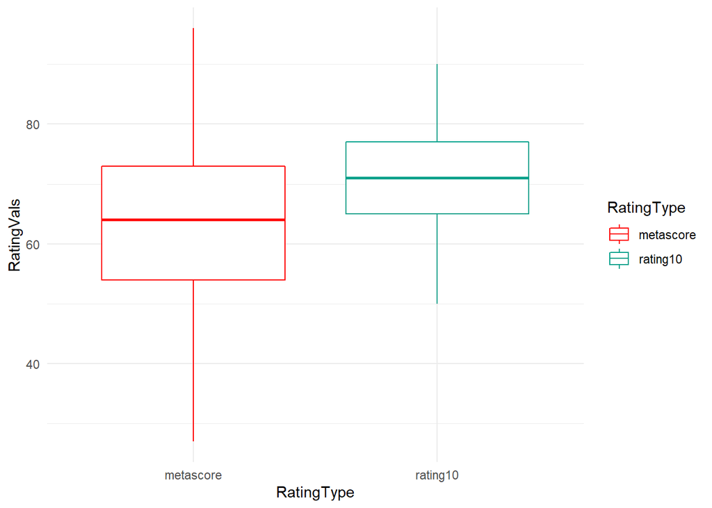

- Metascore has a larger of range of score values than the website ratings

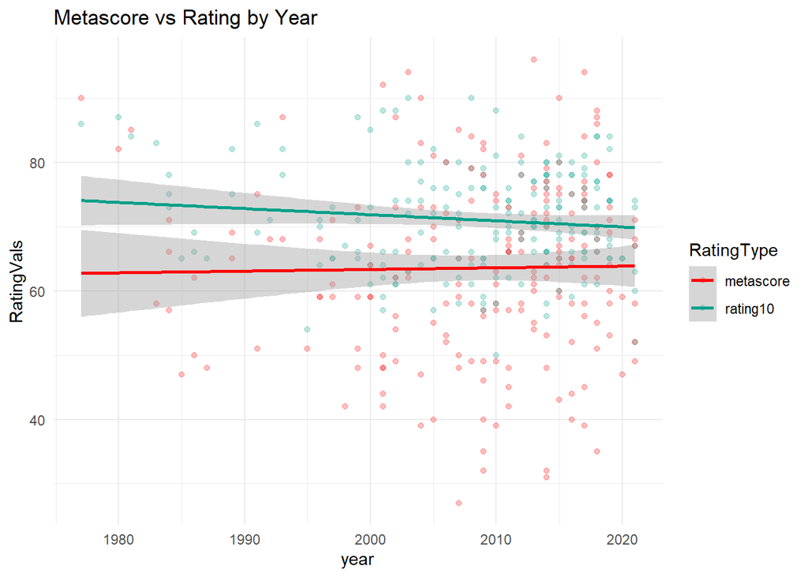

- This pattern has been consistent since the first recorded data.

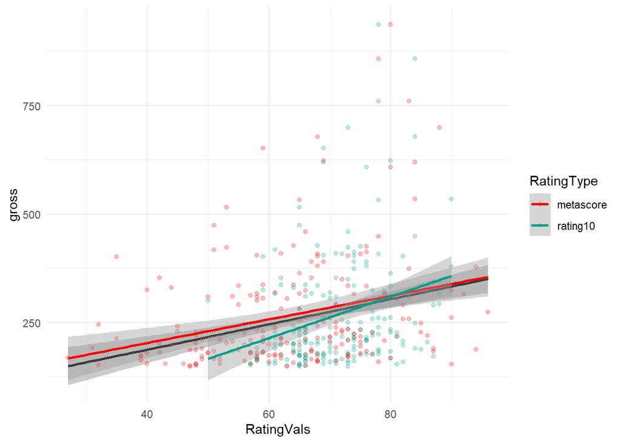

- Higher values of both scores are correlated with a higher gross income of a film.

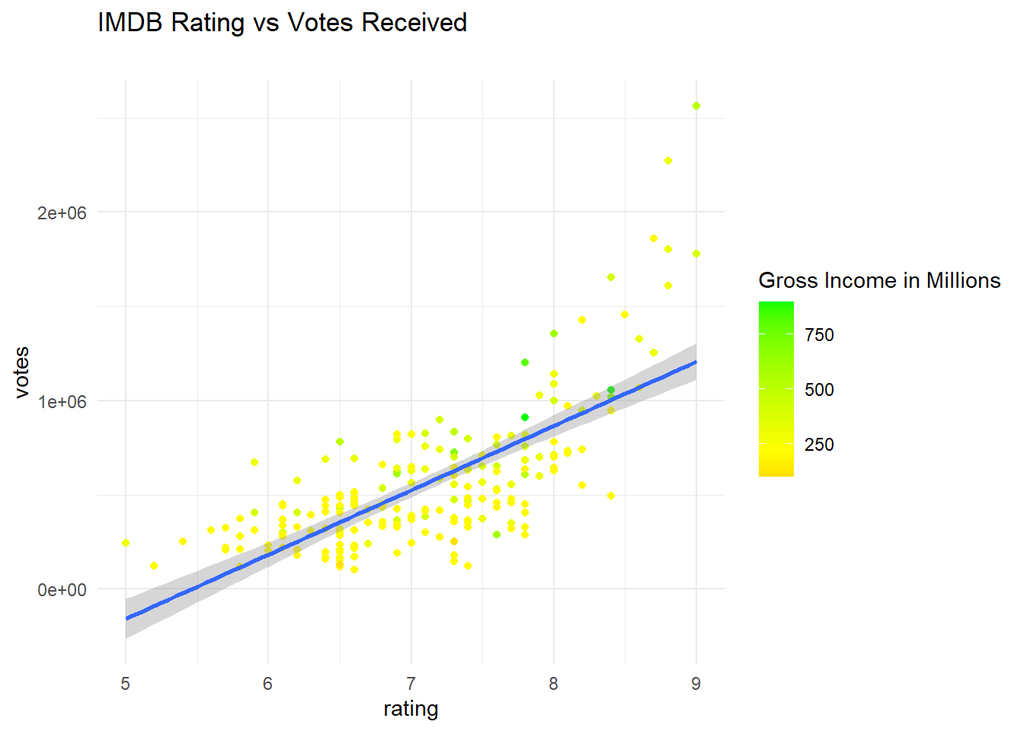

- More votes are highly correlated with higher ratings, and higher grossing movies seem to get more user votes. We will explore this in the next visual

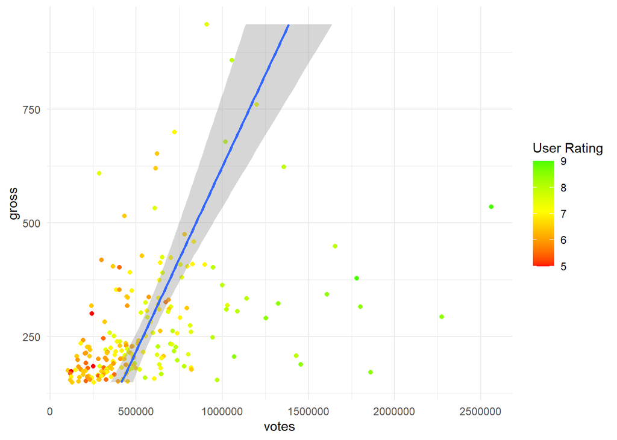

- Number of user votes in the IMDB website, is correlated with higher grossing movies.

# Our Findings

In this study we attempted to find patterns and trends in out data scraped movie data from the IMDB website. We were particularly interested in how the gross income of film was correlated with different variables.

From this data, we can only say that rating of a movie is correlated with gross income. We cannot say whether these rating scores cause a movie to have a higher gross income. In order to have a comprehensive analysis of what makes a high grossing movie, we would need more variables. These variables would include total cost, expand to all genres rather than just action, Ad budget, critic nominations, franchise, etc.